# Not so Ordinary (Least Squares) Regressions

November 4, 2016

## Purpose of the Project

## Overview of Project

- Purpose: to compare different types of regression models
  - Ordinary Least Squares
  - Ridge Regression
  - Lasso Regression
  - Principal Components Regression
  - Partial Least Squares Regression
- Based on Chapter 6 *Linear Model Selection and Regularization* of the book **An Introduction to Statistical Learning** by Gareth James, Daniela Witten, Trevor Hastie and Robert Tibshirani

## Data Used

- Using data that originated from Credit.csv
  - Qualitative Variables: gender, student status, martial status, and ethnicity
  - Quantitative Variables: one's age, the number of credit cards one has, years of education, income measured in thousands of dollars, credit limit, credit rating, and one's average credit card debt
- In analysis, using scaled-credit.csv
  - All of the variables are the same as those in Credit.csv
  - Modified with the **qualitative** by making them dummy variables
  - Then centered the mean and standardized the data so everything is in the same units –> allows for comparison

## Types of Regression

## Ordinary Least Squares (OLS)

- Start off with a linear model
  - Using the Credit data set our model will be \[y \approx \beta_0 + \beta_1*x_1 + \beta_2*x_2 + \dots + \beta_11*x_11\] to describe the relationship between `Balance` and financial and demographic information represented in the \(x_is\).
- Minimizes RSS
  - Minimizing the RSS would be minimizing the error of the prediction
- Minimizing this value over the \(\hat{\beta_i}s\) results in \[\hat{\beta} = (X^TX)^{-1}X^TY\]

## Ridge Regression

- Shrinkage method
- Minimizing \[RSS + \lambda\sum_{j=1}^{p}\beta_j^{2}\] -Tuning parameter, \(\lambda\) which controls the impact of RSS and \(\lambda\sum_{j=1}^{p}\beta_j^{2}\) on the regression cofficents
  - When tuning parameter is large will tend towards zero and when small will give same predictions as OLS
- As \(\lambda\) increases, flexibility of ridge regression decreases and variance of a model will decrease as well –> allows for a better fit model

## Lasso Regression

- Shrinkage method
- Minimizing \[\sum_{i=1}^{n}(y_i-\beta_0-\sum_{j=1}^{p}\beta_jx_{ij})^2+\lambda\sum_{j=1}^{p}|\beta_j|\]
- This method of minimization could result in estimations of the \(\beta_j\) as exactly zero
- Performs a variable selection and only fits a model to a subset of the data

## Principal Components Regression (PCR)

- Dimension Reduction Method
- Theory: A small number of "principal components" can explain the variability in the data and relationship with the response variable
- Tends to fit the model better when the first couple of principal components capture most of the variability

## Partial Least Squares Regression (PLSR)

- PLSR is an extension of principal components regression
- Finds the best linear combinations, but takes into account both the response and predictor variables
- Believe that a set of data \(Z_i\) that would create a better fit for the data than the original data would be
- \(Z_i\) are built in a iterative process
- Once we have \(Z_1, Z_2, \dots, Z_M\) we now fit a linear model in the same way as in PCR

## Why Look at Different Types of Regression?

## Use other models to improve model prediction accuracy

- Ordinary least squares is most effective when the number of observations (n) is much larger than the number of variables (p) in the model due to minimizing variance
- When n >> p is **not true** variance can be large which means there is a wider range of predictions –> accuracy is lowered

## Some variables are not correlated with response variable

- Ordinary least squares will use all predictors even if not all of them are correlated with the response –> can cause analysis to be more complicated
- Other models will set the coefficent of those uncorrelated variables to zero –> will allow for easier analysis

## Results

## Comparing the Coefficents

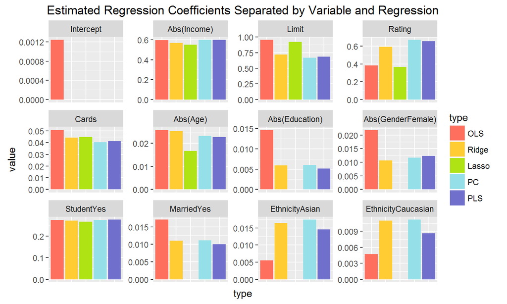

## Comparing the MSEs

Test MSE Values for the Regression Techniques

| Regression | MSE |
| --- | --- |
| OLS | 0.0517916 |
| Ridge | 0.0525927 |
| Lasso | 0.0515445 |
| PCR | 0.0519968 |
| PLSR | 0.0519598 |

## Conclusion

## Findings

### Coefficient Findings

- All but OLS regression has an intercept of exactly zero
- Lasso regression results in some of the coefficients being exactly zero
- Some variables like `Rating` and `Limit` have coefficient estimates that vary widely by different regression types

### MSE Findings

- Lasso = Lowest MSE
- Ridge = Highest MSE